# customerSegmentation

Haizhou Yuan

2024-04-05

Step 1: Data processing and irregular value dealing.

```r
# Download required packages for data processing
# options(repos = c(CRAN = "https://mirror.rcg.sfu.ca/mirror/CRAN/"))
# install.packages("fastDummies")
# install.packages('tidyverse', dependencies=TRUE, type="source")
# install.packages("ggplot2")
# install.packages("lubridate")
# install.packages("dplyr")


library(dplyr)
library(tidyr)
library(lubridate)
library(stringr)
library(fastDummies)
# Read the data
cars_data <- read.csv("car_data.csv") %>%
    mutate(
        Date = mdy(Date), # Convert Date to Date format assuming m/d/y format
        Engine = gsub("Â", "", Engine), # Clean Engine column
        Price = as.numeric(Price), # Ensure numeric
        Gender = ifelse(Gender == "Male", 1, 0)
    ) # Convert Gender to binary


# Na dealing with categorical columns
# Numeric columns: Replace NA with mean
numeric_columns <- sapply(cars_data, is.numeric)
cars_data[numeric_columns] <- lapply(cars_data[numeric_columns], function(x) ifelse(is.na(x), mean(x, na.rm = TRUE), x))

cars_data_encoded <- dummy_cols(cars_data, select_columns = c("Transmission", "Color", "Body_Style", "Engine", "Dealer_Region"))
# Drop the original columns to avoid multicollinearity
cars_data_encoded <- select(cars_data_encoded, -c(Transmission, Color, `Body_Style`, Engine, Dealer_Region))
cars_data_encoded <- fastDummies::dummy_cols(cars_data_encoded, select_columns = "Company", remove_first_dummy = TRUE)
head(cars_data_encoded)
```

```
##         Car_id       Date Customer_Name Gender Annual_Income
## 1 C_CND_000001 2022-01-02     Geraldine      1         13500
## 2 C_CND_000002 2022-01-02           Gia      1       1480000
## 3 C_CND_000003 2022-01-02        Gianna      1       1035000
## 4 C_CND_000004 2022-01-02       Giselle      1         13500
## 5 C_CND_000005 2022-01-02         Grace      1       1465000
## 6 C_CND_000006 2022-01-02     Guadalupe      1        850000
##                           Dealer_Name    Company      Model Price  Dealer_No
## 1 Buddy Storbeck's Diesel Service Inc       Ford Expedition 26000 06457-3834
## 2                    C & M Motors Inc      Dodge    Durango 19000 60504-7114
## 3                         Capitol KIA   Cadillac   Eldorado 31500 38701-8047
## 4              Chrysler of Tri-Cities     Toyota     Celica 14000 99301-3882
## 5                   Chrysler Plymouth      Acura         TL 24500 53546-9427
## 6                       Classic Chevy Mitsubishi   Diamante 12000 85257-3102
##     Phone Transmission_Auto Transmission_Manual Color_Black Color_Pale White
```

[output cut: 83 more lines]

Step 2: Customer segmentation

The Elbow Method is used to determine the optimal number of clusters for K-means clustering. The idea is to run K-means clustering on the dataset for a range of values of (k) (number of clusters) and for each value, calculate the total within-cluster sum of squares (WSS), which is a measure of variance within each cluster.

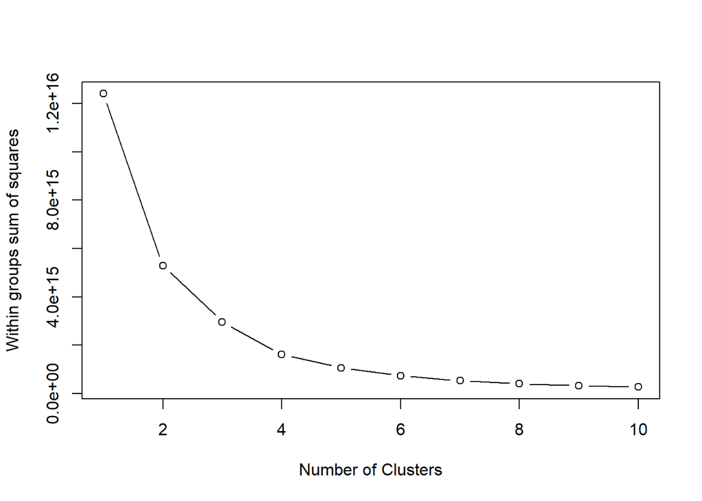

```r
# Compute total within-cluster sum of square
set.seed(123) # Set seed for reproducibility
columns_to_cluster <- c("Annual_Income", "Price")

wss <- sapply(1:10, function(k){
  kmeans(cars_data_encoded[, columns_to_cluster], centers=k, nstart=10 )$tot.withinss
})

# Plot the Elbow Curve
plot(1:10, wss, type="b", xlab="Number of Clusters", ylab="Within groups sum of squares")
```

```r
# Replace K with the optimal number of clusters you determined from the Elbow Method
optimal_k <- 8

# Apply K-means clustering
set.seed(123)

# Clustering based on income, car price and car age
kmeans_result <- kmeans(cars_data_encoded[, columns_to_cluster], centers=optimal_k, nstart=10 )


# Adding the cluster assignment
cars_data_encoded$Cluster <- as.factor(kmeans_result$cluster)
head(cars_data_encoded)
```

```
##         Car_id       Date Customer_Name Gender Annual_Income
## 1 C_CND_000001 2022-01-02     Geraldine      1         13500
## 2 C_CND_000002 2022-01-02           Gia      1       1480000
## 3 C_CND_000003 2022-01-02        Gianna      1       1035000
## 4 C_CND_000004 2022-01-02       Giselle      1         13500
## 5 C_CND_000005 2022-01-02         Grace      1       1465000
## 6 C_CND_000006 2022-01-02     Guadalupe      1        850000
##                           Dealer_Name    Company      Model Price  Dealer_No
## 1 Buddy Storbeck's Diesel Service Inc       Ford Expedition 26000 06457-3834
## 2                    C & M Motors Inc      Dodge    Durango 19000 60504-7114
## 3                         Capitol KIA   Cadillac   Eldorado 31500 38701-8047
## 4              Chrysler of Tri-Cities     Toyota     Celica 14000 99301-3882
## 5                   Chrysler Plymouth      Acura         TL 24500 53546-9427
## 6                       Classic Chevy Mitsubishi   Diamante 12000 85257-3102
##     Phone Transmission_Auto Transmission_Manual Color_Black Color_Pale White
```

[output cut: 83 more lines]

```r
# Summary statistics for Annual_Income and Price by Cluster
company_columns <- grep("^Company_", names(cars_data_encoded), value = TRUE)

# Calculate the most prevalent company in each cluster
most_prevalent_company <- cars_data_encoded %>%
  select(c(Cluster, company_columns)) %>%
  group_by(Cluster) %>%
  summarise(across(all_of(company_columns), sum)) %>%
  pivot_longer(cols = -Cluster, names_to = "Company", values_to = "Count") %>%
  mutate(Company = gsub("Company_", "", Company)) %>%
  arrange(desc(Count)) %>%
  group_by(Cluster) %>%
  slice(1) %>%
  ungroup() %>%
  select(-Count)
summary_stats <- cars_data_encoded %>%
  group_by(Cluster) %>%
  summarise(
    Average_Annual_Income = mean(Annual_Income, na.rm = TRUE),
    Median_Annual_Income = median(Annual_Income, na.rm = TRUE),
    Average_Price = mean(Price, na.rm = TRUE),
    Median_Price = median(Price, na.rm = TRUE)
  ) %>%
  left_join(most_prevalent_company, by = "Cluster")

print(summary_stats)
```

```
## # A tibble: 8 × 6
##   Cluster Average_Annual_Income Median_Annual_Income Average_Price Median_Price
##   <fct>                   <dbl>                <dbl>         <dbl>        <dbl>
## 1 1                    3202762.              3100000        30448.        25701
## 2 2                    2293051.              2260000        28190.        23000
## 3 3                    1691237.              1675000        27760.        22600
## 4 4                    1245606.              1250000        28078.        22600
## 5 5                     531837.               548000        28067.        23000
## 6 6                     846026.               840000        28229.        23501
## 7 7                      16878.                13500        27887.        22001
## 8 8                    5181070.              4940000        29120.        25000
## # ℹ 1 more variable: Company <chr>
```

Step 4: PCA regression

```r
#install.packages("caret")
library(caret)
library(tidyverse)
data_for_pca <- summary_stats %>%
  select_if(is.numeric) %>%
  na.omit()  # Removing rows with NA values

# Scaling the data
data_scaled <- scale(data_for_pca)
pca_result <- prcomp(data_scaled, center = TRUE, scale. = TRUE)
summary(pca_result)
```

```
## Importance of components:
##                           PC1    PC2     PC3     PC4
## Standard deviation     1.8499 0.7343 0.19679 0.01237
## Proportion of Variance 0.8555 0.1348 0.00968 0.00004
## Cumulative Proportion  0.8555 0.9903 0.99996 1.00000
```

```r
pc_data <- as.data.frame(pca_result$x[, 1:2])
pc_data$Average_Price <- summary_stats$Average_Price[!is.na(rowSums(data_for_pca))]  # Matching rows after NA omission

# Linear regression with the principal components
model <- lm(Average_Price ~ ., data = pc_data)
summary(model)
```

```
##
## Call:
## lm(formula = Average_Price ~ ., data = pc_data)
##
## Residuals:
##        1        2        3        4        5        6        7        8
##   73.229   67.650   -2.676   83.839 -105.473 -189.927  121.415  -48.058
##
## Coefficients:
##             Estimate Std. Error t value Pr(>|t|)
## (Intercept) 28472.46      45.06 631.851 1.88e-13 ***
## PC1          -425.03      26.04 -16.321 1.57e-05 ***
## PC2          -569.56      65.61  -8.681 0.000335 ***
## ---
## Signif. codes:  0 '***' 0.001 '**' 0.01 '*' 0.05 '.' 0.1 ' ' 1
##
## Residual standard error: 127.5 on 5 degrees of freedom
## Multiple R-squared:  0.9856, Adjusted R-squared:  0.9798
## F-statistic: 170.9 on 2 and 5 DF,  p-value: 2.497e-05
```

```r
set.seed(123)  # For reproducibility
train_control <- trainControl(method = "cv", number = 10)  # 10-fold cross-validation
model_cv <- train(Average_Price ~ ., data = pc_data, method = "lm", trControl = train_control)
summary(model_cv)
```

```
##
## Call:
## lm(formula = .outcome ~ ., data = dat)
##
## Residuals:
##       X1       X2       X3       X4       X5       X6       X7       X8
##   73.229   67.650   -2.676   83.839 -105.473 -189.927  121.415  -48.058
##
## Coefficients:
##             Estimate Std. Error t value Pr(>|t|)
## (Intercept) 28472.46      45.06 631.851 1.88e-13 ***
## PC1          -425.03      26.04 -16.321 1.57e-05 ***
## PC2          -569.56      65.61  -8.681 0.000335 ***
## ---
## Signif. codes:  0 '***' 0.001 '**' 0.01 '*' 0.05 '.' 0.1 ' ' 1
##
## Residual standard error: 127.5 on 5 degrees of freedom
## Multiple R-squared:  0.9856, Adjusted R-squared:  0.9798
## F-statistic: 170.9 on 2 and 5 DF,  p-value: 2.497e-05
```

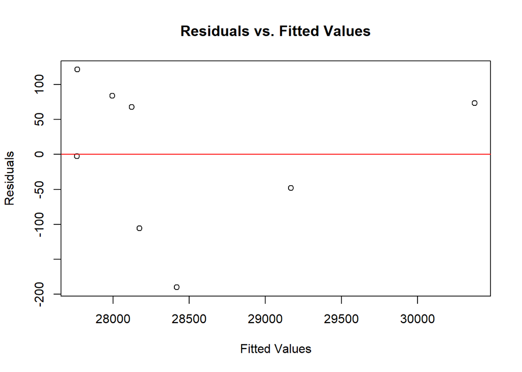

```r
# Plotting residuals vs. fitted values
plot(model$fitted.values, resid(model),
     xlab = "Fitted Values", ylab = "Residuals",
     main = "Residuals vs. Fitted Values")
abline(h = 0, col = "red")
```

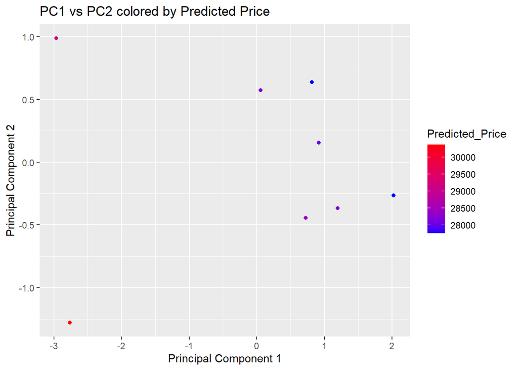

```r
pc_data$Predicted_Price <- predict(model, newdata = pc_data)
ggplot(pc_data, aes(x = PC1, y = PC2, color = Predicted_Price)) +
  geom_point() +
  scale_color_gradient(low = "blue", high = "red") +
  labs(title = "PC1 vs PC2 colored by Predicted Price",
       x = "Principal Component 1", y = "Principal Component 2")
```

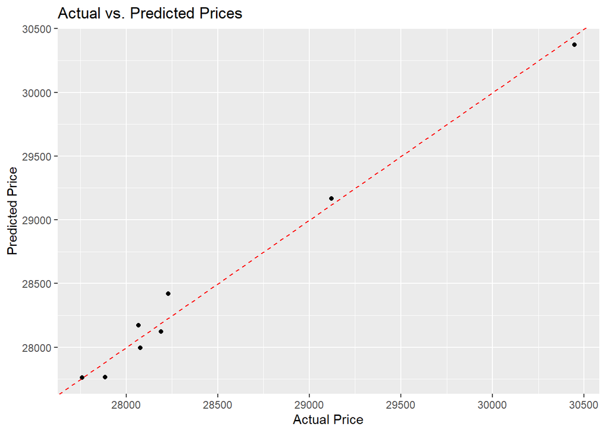

```r
ggplot(pc_data, aes(x = Average_Price, y = Predicted_Price)) +
  geom_point() +
  geom_abline(intercept = 0, slope = 1, linetype = "dashed", color = "red") +
  labs(title = "Actual vs. Predicted Prices",
       x = "Actual Price", y = "Predicted Price")
```

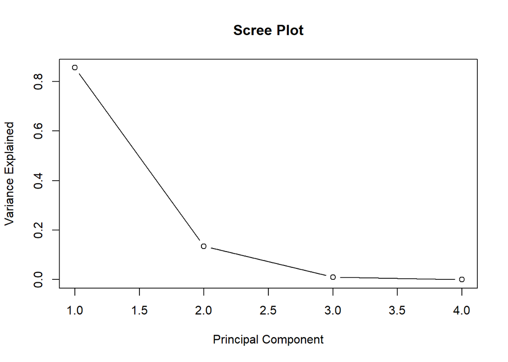

```r
# Scree plot
plot(pca_result$sdev^2 / sum(pca_result$sdev^2), xlab="Principal Component", ylab="Variance Explained", type='b', main="Scree Plot")
```

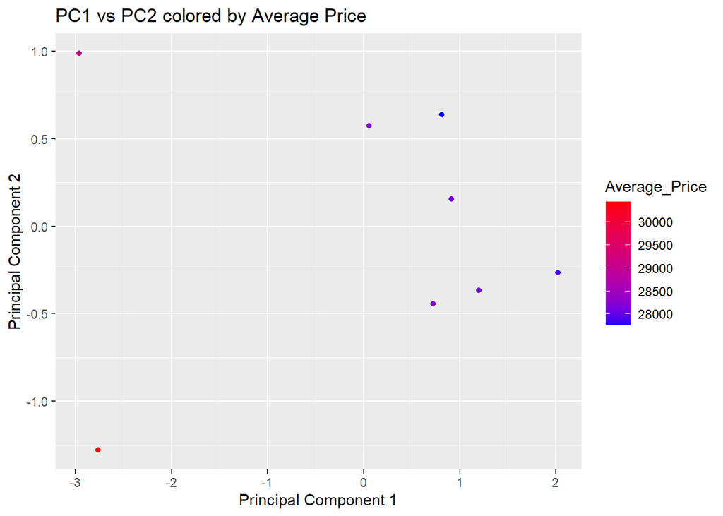

```r
library(ggplot2)

# PCA data plot
ggplot(pc_data, aes(x=PC1, y=PC2, color=Average_Price)) +
  geom_point() +
  scale_color_gradient(low="blue", high="red") +
  labs(title="PC1 vs PC2 colored by Average Price", x="Principal Component 1", y="Principal Component 2")
```

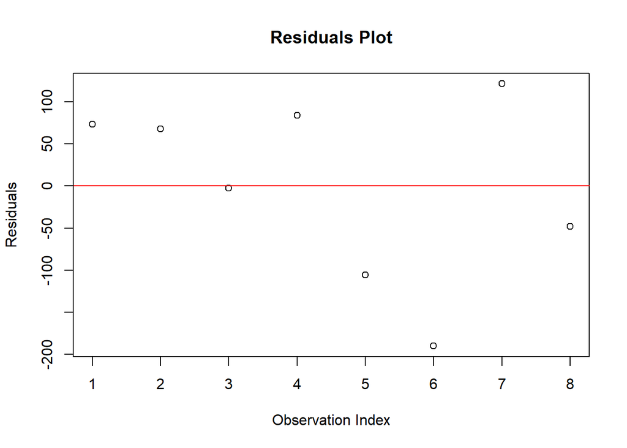

```r
# Plotting residuals
plot(model$residuals, type='p', main="Residuals Plot", ylab="Residuals", xlab="Observation Index")
abline(h=0, col="red")
```

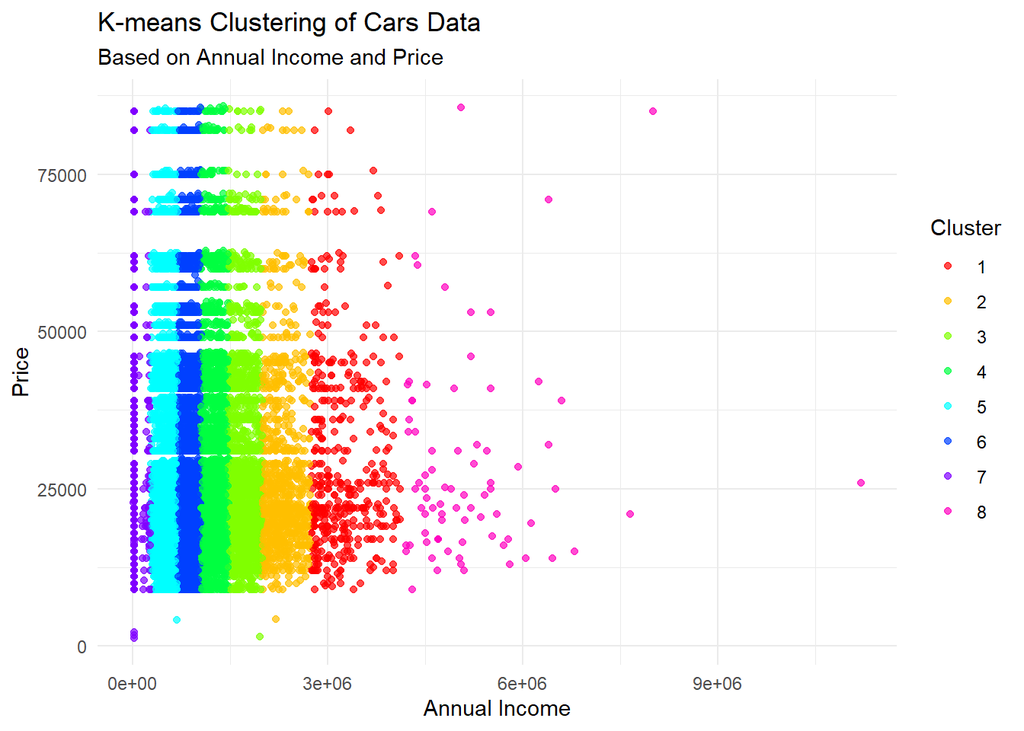

```r
ggplot(cars_data_encoded, aes(x = Annual_Income, y = Price, color = Cluster)) +
  geom_point(alpha = 0.7) +  # Adjust point transparency with alpha
  scale_color_manual(values = rainbow(length(unique(cars_data_encoded$Cluster)))) +  # Color coding by cluster
  theme_minimal() +
  labs(title = "K-means Clustering of Cars Data",
       subtitle = "Based on Annual Income and Price",
       x = "Annual Income",
       y = "Price",
       color = "Cluster") +
  theme(legend.position = "right")  # Adjust legend position as needed
```

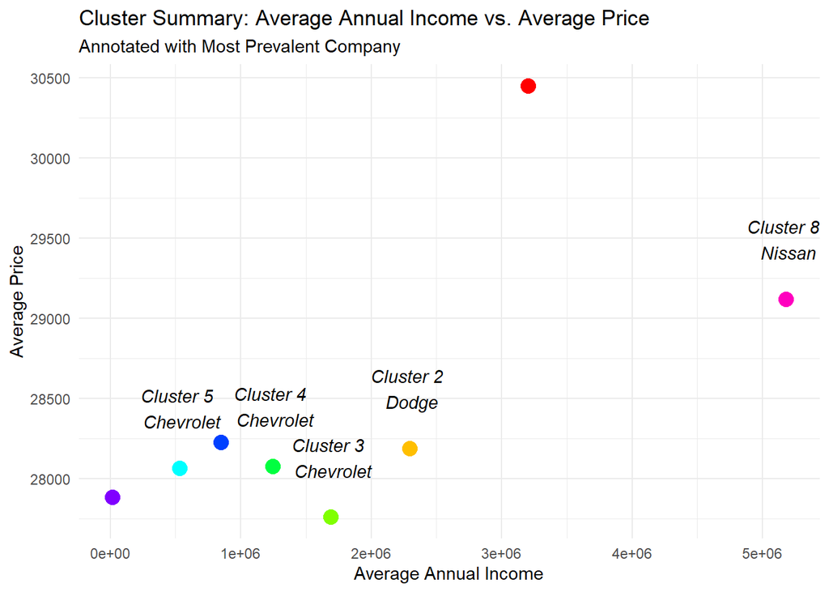

```r
ggplot(summary_stats, aes(x = Average_Annual_Income, y = Average_Price, label = Cluster)) +
  geom_point(aes(color = Cluster), size = 4) +  # Plot average income vs. price, colored by cluster
  geom_text(aes(label = paste("Cluster", Cluster, "\n", Company)),
            vjust = -1, hjust = 0.5, check_overlap = TRUE, fontface = "italic") +  # Annotate with company
  scale_color_manual(values = rainbow(n = length(unique(summary_stats$Cluster)))) +  # Custom colors
  theme_minimal() +
  labs(title = "Cluster Summary: Average Annual Income vs. Average Price",
       subtitle = "Annotated with Most Prevalent Company",
       x = "Average Annual Income",
       y = "Average Price",
       color = "Cluster") +
  theme(legend.position = "none")  # Hide legend if cluster labels are clear
```

PCA Results

PC1 (Principal Component 1) explains a substantial majority of the variance within the dataset, with a proportion of variance of 85.55%. This indicates that PC1 captures most of the underlying structure or pattern in the data. PC2 accounts for an additional 13.48% of the variance, bringing the cumulative proportion of variance explained by the first two components to 99.03%. The contributions of PC3 and PC4 to explaining the variance are minimal, at 0.968% and 0.004%, respectively. Given these results, it’s clear that most of the information in the dataset can be effectively represented by the first two principal components, making them suitable candidates for use in further analyses, such as regression modeling.

Regression Analysis The regression analysis, utilizing PC1 and PC2 as predictors for Average_Price, yielded the following key results:

Coefficients: Both PC1 and PC2 have significant negative coefficients, -425.03 and -569.56, respectively, with very low p-values (PC1: 1.57e-05, PC2: 0.000335). This indicates a strong, statistically significant relationship between these principal components and the Average_Price. The negative coefficients suggest that as the values of PC1 and PC2 increase, the Average_Price tends to decrease. Intercept: The intercept value is 28472.46, with a very low p-value, indicating the average Average_Price when PC1 and PC2 are at their mean values (due to the scaling in PCA). Model Fit: The model has an exceptionally high Multiple R-squared of 0.9856, suggesting that 98.56% of the variability in Average_Price can be explained by PC1 and PC2. The Adjusted R-squared is 0.9798, which adjusts for the number of predictors and essentially provides the same interpretation in this context due to the high explanatory power of the model. F-Statistic: The F-statistic value is 170.9 with a p-value of 2.497e-05, indicating that the model is statistically significant. This means that there is a very low probability that these results could have occurred by chance, further validating the relationship between the principal components and Average_Price. Conclusion and Considerations The PCA followed by regression analysis indicates a strong and statistically significant model for predicting Average_Price based on the first two principal components derived from the dataset. The high R-squared value suggests an excellent fit, though it is essential to consider the risk of overfitting, especially given the small sample size (as indicated by the degrees of freedom in the regression analysis).

Moreover, while the PCA has effectively reduced the dimensionality of the dataset and the regression model shows strong predictive power, the interpretation of the principal components themselves can be more challenging compared to using original variables. Each principal component is a linear combination of the original variables, and understanding their specific impact on Average_Price requires further analysis of the PCA loadings.

Finally, it’s crucial to validate these findings with additional data or through cross-validation to ensure the model’s generalizability and robustness.